# Genetic diversity

# 3 Nucleotide diversity (π)

Nucleotide diversity (π), is the average number of differences per base between two randomly chosen copies of the genome in a population. For example, π = 0.005 means that two copies differ at about 1 in every 200 bases. Every individual carries two copies of the genome, so π is also the heterozygosity per base we would expect if the population mated at random. Nucleotide diversity also assumes neutrality (Natural selection violates this by increasing/decreasing diversity at sites).

We often calculate π in **windows** along the genome. These windows don’t overlap: each one starts where the last one ended. (`--window-pi-step` lets you make them overlap, remember our sliding windows from lass class!)

Here we will use 10kb windows across the entire genome for an initial look.

## 3.1 All samples together

```bash
mkdir -p pi ##make subdirectory for pi data
vcftools --gzvcf $VCF --window-pi 10000 --out pi/all
head pi/all.windowed.pi
##
rm pi/all*
```

You should have a file with `.pi` ending that contains the following:

| Column | Contains |
| --- | --- |
| `CHROM` | The scaffold |
| `BIN_START`, `BIN_END` | The start and end base position of the window |
| `N_VARIANTS` | The number of SNPs in the window |
| `PI` | Nucleotide diversity in the window |

## 3.2 Each population

Now we can loop over our population files and calculate π for each site in turn, we dont want to do this manually as we have alot of populations, so loop saves us time and coding space.

```bash
WINDOW=10000 ###we can change this but keep the code teh same to test multiple window sizes

for KEEP in pops/*.txt; do
    POP=$(basename $KEEP .txt)   # e.g. pops/BOD.txt -> BOD
    echo "== $POP =="
    vcftools --gzvcf $VCF \
        --keep $KEEP \
        --window-pi $WINDOW \
        --out pi/$POP
done

###check the files exist and its how many you expect
ls pi
ls -l pi/*.pi | wc -l
```

`for KEEP in pops/*.txt` runs the loop once for each file in the `pops` folder. `basename` strips the folder and the `.txt` ending from the file name to give us the site name, which we use to name the output.

**WarningWhy vcftools π is only approximate**

vcftools calculates π for a window by adding up the differences at each SNP and dividing by the window length. That has some consequences:

- **Missing bases count as invariant.** Our VCF only contains SNPs, so vcftools assumes every other base in the window was sequenced and identical in everyone. Bases that were never sequenced, or were filtered out, are counted as invariant, which affects the calculation of nucleotide diversity.
- **Short scaffolds.** Windows on scaffolds shorter than 10 kb are still divided by 10,000, so their π is too low too. Our reference has a lot of short scaffolds.
- **Empty windows are left out.** Windows with no SNPs don’t appear in the output, rather than being reported as π = 0, so averaging the windows overestimates π.

So treat vcftools π as a relative measure. Comparing populations from the same VCF is reasonable, as long as they have similar amounts of missing data, but don’t compare the values with other studies. To estimate π properly you need a VCF that also includes the invariant sites (an “all-sites” VCF) and a program such as [pixy](https://pixy.readthedocs.io), which only counts the bases that were actually genotyped. Pixy is what we tend to use, but its a little fiddly as it uses a conda environment and we arent going to go into that.

**TipQuestion**

Compare the average π across all samples (`all.windowed.pi`) with the average for each site. Which is higher, and why?

# 4 Tajima’s *D*

Tajima’s *D* compares two estimates of genetic diversity to test for divergence from neutrality across the genome.

- **π**, the average number of differences between pairs of sequences. Variants at intermediate frequency contribute the most to π.
- **Watterson’s θ** (θ<sub>W</sub>), based on the number of variable sites. Every variant counts the same here, however rare it is.

*D* is the difference between the two (π − θ<sub>W</sub>), scaled by its standard deviation. Rare variants raise θ<sub>W</sub> much more than they raise π.

The formula is:

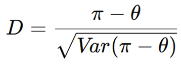

| Tajima’s *D* | The population has… | Possible causes |
| --- | --- | --- |
| ≈ 0 | The allele frequencies we expect | Neutral evolution at a constant population size |
| Negative | An excess of **rare** variants | Population expansion; a recent selective sweep (positive selection); purifying selection |
| Positive | An excess of **intermediate-frequency** variants | Population decline (a bottleneck); balancing selection |

Demography and selection can push *D* in the same direction, so how do we tell them apart? Demography affects the whole genome, whereas selection affects particular regions. A shift in *D* across the whole genome (most windows positive, say) points to demography. Windows that stand out from the rest of the genome are candidates for selection.

You’ll often see |*D*| > 2 used as a rule of thumb for significance, but that relies on assumptions that rarely hold for genome-wide sequencing data. *D* is best used as a relative measure: compare windows and populations that were processed in the same way, and look for windows that are outliers compared with the rest of the genome.

**WarningTajima’s D needs the rare variants**

*D* depends on the balance of rare and common variants, so anything that removes rare variants pushes *D* upwards. That includes minor allele frequency (MAF) filters and low coverage, where rare variants are easily missed. For Tajima’s *D*, use a VCF without a MAF filter, and compare windows and populations with each other rather than reading too much into the absolute values.

## 4.1 All samples together

```bash
cd $DATA_DIR #lets make sure we are still in mydata
mkdir -p TajD

#this time we need to use the rare alleles too
VCF2=Lottia_gigantea_pl_flt3_noMAF_sub0.01.vcf.gz
echo $VCF2 ##check its the right VCF

vcftools --gzvcf $VCF2 --TajimaD 10000 --out TajD/all
head TajD/all.Tajima.D
##lets remove this
rm TajD/all*
```

| Column | Contains |
| --- | --- |
| `CHROM` | The scaffold |
| `BIN_START` | The start of the window. Careful: this counts from 0, unlike the π output, which counts from 1! |
| `N_SNPS` | The number of SNPs in the window |
| `TajimaD` | Tajima’s *D* for the window (`nan` if it can’t be calculated) |

Windows with only a handful of SNPs give very unreliable values of *D*, so when we plot we will only keep windows with at least 5 SNPs.

## 4.2 Each population

```bash
WINDOW=10000

for KEEP in pops/*.txt; do
    POP=$(basename $KEEP .txt)
    echo "== $POP =="
    vcftools --gzvcf $VCF2 \
        --keep $KEEP \
        --TajimaD $WINDOW \
        --out TajD/$POP
done

ls TajD
```

**WarningWatch your backslashes**

If you split a command over several lines, every line except the last must end with `\`. Miss one and bash treats the next line as a new command. For example, without the `\` after `--TajimaD $WINDOW`, vcftools never sees `--out`, so it writes every population to the default file `out.Tajima.D`, each one overwriting the last. Then bash complains `--out: command not found`.

**TipQuestion**

Is Tajima’s *D* higher for all samples together, or within each site? Look back at the table above, why might that be?

# 5 Heterozygosity

- **Observed heterozygosity (*H*<sub>O</sub>)** is the proportion of sites at which an individual is heterozygous.
- **Expected heterozygosity (*H*<sub>E</sub>)** is the proportion we would expect if the population mated at random (Hardy–Weinberg equilibrium): 2*pq* at each site, where *p* and *q* are the allele frequencies.
- The **inbreeding coefficient** compares the two: *F* = 1 − *H*<sub>O</sub> / *H*<sub>E</sub>. *F* = 0 means an individual is as heterozygous as expected, *F* > 0 means less heterozygous, and *F* < 0 means more.

| *F* | Possible causes |
| --- | --- |
| Positive (too few heterozygotes) | Inbreeding (mating between relatives); genotyping errors, especially at low coverage, where heterozygotes are miscalled as homozygotes |
| Negative (too many heterozygotes) | Mating between divergent populations; mapping errors, where reads from duplicated regions (paralogs) pile up on one locus and look like heterozygotes in everyone |

## 5.1 All samples together

```bash
cd $DATA_DIR
mkdir -p het

###note back to the normal VCF, use echo to check
vcftools --gzvcf $VCF --het --out het/all
head het/all.het
##lets remove this
rm het/all*
```

| Column | Contains |
| --- | --- |
| `INDV` | The sample ID |
| `O(HOM)` | The number of sites at which the individual is homozygous (observed) |
| `E(HOM)` | The number of homozygous sites expected under Hardy–Weinberg equilibrium |
| `N_SITES` | The number of sites with a genotype for this individual |
| `F` | The inbreeding coefficient |

There’s no column for observed heterozygosity, but we can calculate it: *H*<sub>O</sub> = (`N_SITES` − `O(HOM)`) / `N_SITES`. We’ll do this in R later.

## 5.2 Each population

When we run all samples together, the expected heterozygosity comes from the allele frequencies of *everyone*. Running each population separately means the metrics are measured relative to an individual’s own population:

```bash
for KEEP in pops/*.txt; do
    POP=$(basename $KEEP .txt)
    echo "== $POP =="
    vcftools --gzvcf $VCF \
        --keep $KEEP \
        --het \
        --out het/$POP
done
```

**Note**

When run on one population, vcftools only uses the sites that are variable *within that population*, so `N_SITES` differs between populations. Use the all-samples run to compare *H*<sub>O</sub> between individuals, and the per-population runs for *F*.

**WarningLow coverage hides heterozygotes**

At a heterozygous site, each read comes from one of the two alleles at random, like tossing a coin. With 3 reads, the chance that they all come from the same allele is 2 × (½)<sup>3</sup> = 25%, so about a quarter of heterozygotes look homozygous. With 10 reads, the chance drops to 2 × (½)<sup>10</sup> ≈ 0.2%.

Variant callers use more information than this, but the problem remains: at low coverage, *H*<sub>O</sub> is underestimated and *F* is overestimated, and individuals with lower depth look less heterozygous than they really are.

So, with low coverage data its often better to use other metrics (e.g., nucleotide diversity) as we cant confidently call heterozygotes.

# 6 Plotting in R

**Note**

The subset results are scaled down and noisy, so to see the real patterns, copy the results I generated from the full VCF. They are found at `/gpfs1/cl/biol3990/PopulationGenomics/diversity/`

Open R or switch to console if in R studio.

```r
library(tidyverse)

setwd("~</my/directory/path>/PopulationGenomics/mydata")

##we want to output results to myresults
OUTDIR="~</my/directory/path>/PopulationGenomics/myresults"

meta <- read_csv("sample_metadata.csv")

# one latitude per site, so we can order the sites north to south
sites <- meta %>%
  group_by(Population) %>%
  summarise(Latitude = mean(Latitude))
```

## 6.1 Nucleotide diversity

Each population’s results are in a separate file, so we read them all in and stack them into one table, taking the site name from the file name:

```r
# the files to read: pi/BOD.windowed.pi, pi/PGR.windowed.pi, ...
pi_files <- list.files("pi", pattern = "windowed.pi$", full.names = TRUE)

pi <- pi_files %>%
  # name each file by its site, e.g. "pi/BOD.windowed.pi" -> "BOD"
  set_names(str_remove(basename(pi_files), fixed(".windowed.pi"))) %>%
  # read every file and stack them, putting the names in a new column, Site
  map_dfr(read_tsv, .id = "Population", show_col_types = FALSE) %>%
  left_join(sites, by = "Population") %>%
  mutate(Site = fct_reorder(Population, Latitude))

# summarise pi for each site
pi_summary <- pi %>%
  group_by(Population, Latitude) %>%
  summarise(n_windows = n(),
            mean_pi   = mean(PI),
            median_pi = median(PI),
            .groups = "drop")
pi_summary
```

```r
dir.create(paste0(OUTDIR,"/pi"))

pi_plot <- ggplot(pi, aes(Site, PI, fill = Site)) +
  geom_violin(scale = "width", linewidth = 0.5, colour = NA) +
  geom_boxplot(width = 0.15, outlier.shape = NA, linewidth = 0.3) +
  scale_fill_viridis_d(end = 0.9) +
  scale_y_log10() +
  labs(x = "Population", y = "log10(Nucleotide diversity)") +
  theme_classic() +
  theme(legend.position = "none") +
  coord_flip()

ggsave(paste0(OUTDIR, "/pi/pi_by_site.png"), plot = pi_plot, width = 6, height = 6)

# does diversity change with latitude?
pi_lat_plot <- ggplot(pi_summary, aes(Latitude, mean_pi)) +
  geom_point(size = 4, shape =21, fill = "cadetblue2", stroke =1.5) +
  labs(x = "Latitude (°N)", y = "Nucleotide diversity", colour = "Site") +
  theme_classic()+
  theme(legend.position = "none")
  coord_flip()

ggsave(paste0(OUTDIR, "/pi/pi_vs_latitude.png"), plot = pi_lat_plot, width = 7, height = 7)
```

## 6.2 Tajima’s *D*

```r
dir.create(paste0(OUTDIR,"/TajD"))


taj_files <- list.files("TajD", pattern = "Tajima.D$", full.names = TRUE)

tajd <- taj_files %>%
  set_names(str_remove(basename(taj_files), fixed(".Tajima.D"))) %>%
  # vcftools writes "nan" when D can't be calculated, so treat that as missing (NA)
  map_dfr(read_tsv, .id = "Population", na = c("", "NA", "nan", "-nan"),
          show_col_types = FALSE) %>%
  filter(N_SNPS >= 5) %>%   # drop windows with too few SNPs to be reliable
  left_join(sites, by = "Population") %>%
  mutate(Site = fct_reorder(Population, Latitude))

tajd %>%
  group_by(Site) %>%
  summarise(n_windows = n(),
            mean_D    = mean(TajimaD, na.rm = TRUE),
            median_D  = median(TajimaD, na.rm = TRUE))

tajd_plot <- ggplot(tajd, aes(Site, TajimaD, fill = Site)) +
  geom_hline(yintercept = 0, linetype = "dashed") +
  geom_violin() +
  geom_boxplot(width = 0.15, fill = "white", outlier.shape = NA) +
  scale_fill_viridis_d(end = 0.9) +
  labs(x = "Site", y = "Tajima's D") +
  theme_classic() +
  theme(legend.position = "none")+
  coord_flip()

ggsave(paste0(OUTDIR, "/TajD/tajimasD_by_site.png"), plot = tajd_plot, width = 4, height = 7)
```

## 6.3 Diversity along the genome

Finally, let’s look at how π varies along one scaffold. We’ll pick the scaffold with the most windows:

```r
top_scaffold <- pi %>%
  count(CHROM, sort = TRUE) %>%
  slice(1) %>%
  pull(CHROM)

scan_plot <- pi %>%
  filter(CHROM == top_scaffold) %>%
  ggplot(aes(BIN_START / 1e6, PI, colour = Site)) +
  geom_line(alpha=0.3) +
  scale_colour_viridis_d(end = 0.9) +
  labs(x = paste(top_scaffold, "position (Mb)"), y = "Nucleotide diversity",
       colour = "Site") +
  theme_bw()

ggsave(paste0(OUTDIR, "/pi/pi_along_scaffold.png"), plot = scan_plot, width = 12, height = 6)
```

## 6.4 Heterozygosity

Now lets compare observed heterozygosity and F across the populations

```r
dir.create(paste0(OUTDIR, "/het"))

het_files <- list.files("het", pattern = "het$", full.names = TRUE)

het_all <- read_tsv(het_files, id = "file", show_col_types = FALSE) %>%
  rename(ID = INDV, O_HOM = `O(HOM)`, E_HOM = `E(HOM)`) %>%
  mutate(
    Pop = tools::file_path_sans_ext(basename(file)),  # e.g. het/SiteA.het -> SiteA
    Ho  = (N_SITES - O_HOM) / N_SITES
  ) %>%
  select(-file) %>%
  left_join(meta, by = "ID") %>%
  mutate(Site = fct_reorder(Site, -Latitude))


##lets make one of my favuorite types of plots (raincloud)

library(ggdist)
#install.packages("ggdist")


ho_plot <- ggplot(het_all, aes(Site, Ho, fill = Site)) +
  geom_jitter(width = 0.05, alpha = 0.6, shape = 21, stroke =1.5) +
  geom_violin(alpha = 0.6) +
  geom_boxplot(width = 0.15, fill = "white", outlier.shape = NA, alpha =0.5) +
  scale_fill_viridis_d(end = 0.9) +
  labs(x = "", y = "Observed heterozygosity") +
  theme_classic() +
  theme(axis.text.x = element_text(angle=45, hjust =1))+
  theme(legend.position = "none")


ggsave(paste0(OUTDIR, "/het/Ho_by_site.png"), plot = ho_plot, width = 4, height = 12)


ho_plot <- ggplot(het_all, aes(x = Site, y = Ho, fill = Site)) +
  geom_jitter(width = 0.05, height = 0, shape = 21, stroke = 0.8, alpha = 0.6, size = 1.4) +
  geom_boxplot(width = 0.12, fill = "white", outlier.shape = NA, alpha = 0.5,
               position = position_nudge(x = 0.25)) +
  ggdist::stat_halfeye(
    adjust = 0.5, width = 0.6, justification = -0.5,
    .width = 0, point_colour = NA, alpha = 0.7
  ) +
  scale_fill_viridis_d(end = 0.9) +
  coord_flip() +
  labs(x = "", y = "Observed heterozygosity") +
  theme_classic() +
  theme(legend.position = "none")

ggsave(paste0(OUTDIR, "/het/Ho_by_site.png"), plot = ho_plot, width = 5, height = 8)


F_plot <- ggplot(het_all, aes(x = Site, y = F, fill = Site)) +
  geom_jitter(width = 0.05, height = 0, shape = 21, stroke = 0.8, alpha = 0.6, size = 1.4) +
  geom_boxplot(width = 0.12, fill = "white", outlier.shape = NA, alpha = 0.5,
               position = position_nudge(x = 0.25)) +
  ggdist::stat_halfeye(
    adjust = 0.5, width = 0.6, justification = -0.5,
    .width = 0, point_colour = NA, alpha = 0.7
  ) +
  scale_fill_viridis_d(end = 0.9) +
  coord_flip() +
  labs(x = "", y = "F Coefficient") +
  theme_classic() +
  theme(legend.position = "none")

ggsave(paste0(OUTDIR, "/het/F_by_site.png"), plot = F_plot, width = 5, height = 8)
```

# 7 Exercises

1. Re-run π and Tajima’s *D* with 50 kb windows. How do the distributions change? What do you gain and lose with bigger windows?
2. Running the per-population loops on the full VCF takes a long time. Can you write a batch job to run these analyses on the full data?
3. For a challenge, read the pixy documentation. What would be needed to generate pi data here?